# CS 422 Section 02

Nicholas Saveas

# CS 422 HW 3 Practicum Problems

## Exercise 2.1-a

#### Exercise 2.1-a-i

I don’t want to remove any of the attributes - I think they are all valuable pieces of information.

#### Exercise 2.1-a-ii

I don’t think the attributes should be standardized because they all have the same unit: amount of teeth.

#### Exercise 2.1-a-iii

See archive for file19.csv

```r
setwd("C:/Users/Nicko/Documents/School/Spring_2018/CS_422_Data_Mining/HW3/")
mammals.df <- read.csv("file19.csv", sep=",", header=T, comment.char = "#", row.names = 1)
```

## Exercise 2.1-b

#### 2.1-b-i

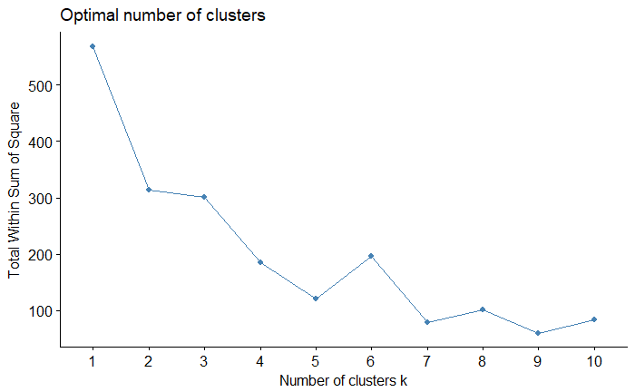

```r
library(cluster)
library(ggplot2)
library(factoextra)
fviz_nbclust(mammals.df, FUNcluster = kmeans, method = "wss")
```

#### 2.1-b-ii

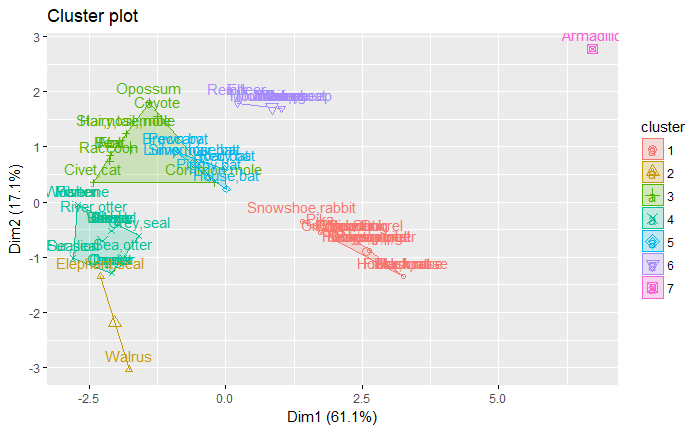

```r
mammals.k <- kmeans(mammals.df, centers=7, nstart=25)
fviz_cluster(mammals.k, data=mammals.df)
```

#### 2.1-b-iii

```r
mammals.k$size
```

```
[1] 19  2 10 17  8  9  1
```

Cluster 1: 19 // Cluster 2: 2 // Cluster 3: 10 // Cluster 4: 17 // Cluster 5: 8 // Cluster 6: 9 // Cluster 7: 1

#### 2.1-b-iv

```r
mammals.k$totss
```

```
[1] 568.303
```

#### 2.1-b-v

```r
mammals.k$withinss
```

```
[1] 23.473684  3.000000 21.100000 20.705882  6.375000  1.555556  0.000000
```

Cluster 1: 23.47 // Cluster 2: 3.00 // Cluster 3: 21.10 // Cluster 4: 20.71 // Cluster 5: 6.38 // Cluster 6: 1.56 // Cluster 7: 0.00

#### 2.1-b-vi

```r
for (number in c(1,2,3,4,5,6,7)) {
  print(paste(which(mammals.k$cluster == number)))
}
```

```
 [1] "13" "14" "15" "16" "17" "18" "19" "20" "21" "22" "23" "24" "25" "26" "27" "28" "29" "30" "31"
[1] "54" "56"
 [1] "1"  "2"  "3"  "4"  "32" "33" "34" "35" "36" "37"
 [1] "38" "39" "40" "41" "42" "43" "44" "45" "46" "47" "48" "49" "50" "51" "52" "53" "55"
[1] "5"  "6"  "7"  "8"  "9"  "10" "11" "57"
[1] "58" "59" "60" "61" "62" "63" "64" "65" "66"
[1] "12"
```

```r
mammals.df
```

|  | I | i | C | c | P | p | M | m |
| --- | --- | --- | --- | --- | --- | --- | --- | --- |
| Opossum | 5 | 4 | 1 | 1 | 3 | 3 | 4 | 4 |
| Hairy,tail,mole | 3 | 3 | 1 | 1 | 4 | 4 | 3 | 3 |
| Common,mole | 3 | 2 | 1 | 0 | 3 | 3 | 3 | 3 |
| Star,nose,mole | 3 | 3 | 1 | 1 | 4 | 4 | 3 | 3 |
| Brown,bat | 2 | 3 | 1 | 1 | 3 | 3 | 3 | 3 |
| Silver,hair,bat | 2 | 3 | 1 | 1 | 2 | 3 | 3 | 3 |
| Pigmy,bat | 2 | 3 | 1 | 1 | 2 | 2 | 3 | 3 |
| House,bat | 2 | 3 | 1 | 1 | 1 | 2 | 3 | 3 |
| Red,bat | 1 | 3 | 1 | 1 | 2 | 2 | 3 | 3 |
| Hoary,bat | 1 | 3 | 1 | 1 | 2 | 2 | 3 | 3 |

[output cut: 56 more lines]

I think its interesting that most of the indicies are consecutive, which leads me to believe that the points are clustered mostly correctly - assuming that the data was entered in some order that thought about the types of mammals. The first couple of indicies are only moles and then there are bats, etc. Some animals are probaly misplaced but overall it seems correct.

Also the points within their cluster - at least the points you can read - seem to have some relationship with each other.

## Exercise 2.2

#### Exercise 2.2-a

```r
languages.df <- read.csv("file46.csv", sep=",", header=T, comment.char = "#", row.names = 1)
```

```r
languages.single <- eclust(languages.df, FUNcluster = "hclust", hc_method = "single")
```

```
Clustering k = 1,2,..., K.max (= 10): .. done
Bootstrapping, b = 1,2,..., B (= 100)  [one "." per sample]:
.................................................. 50
.................................................. 100
```

```r
languages.complete <- eclust(languages.df, FUNcluster = "hclust", hc_method = "complete")
```

```
Clustering k = 1,2,..., K.max (= 10): .. done
Bootstrapping, b = 1,2,..., B (= 100)  [one "." per sample]:
.................................................. 50
.................................................. 100
```

```r
languages.average <- eclust(languages.df, FUNcluster = "hclust", hc_method = "average")
```

```
Clustering k = 1,2,..., K.max (= 10): .. done
Bootstrapping, b = 1,2,..., B (= 100)  [one "." per sample]:
.................................................. 50
.................................................. 100
```

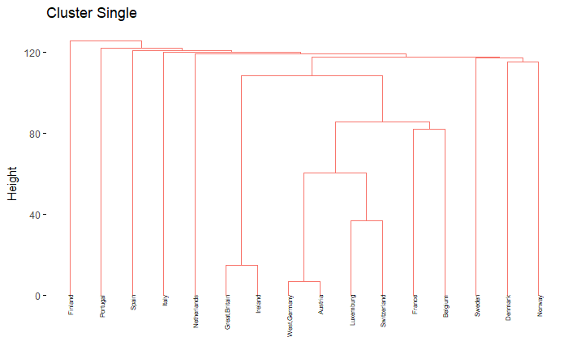

```r
fviz_dend(languages.single, main = "Cluster Single", cex = 0.4, label_cols = "black")
```

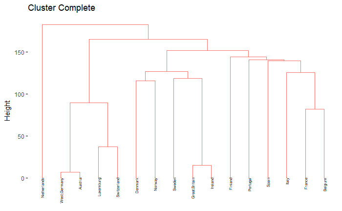

```r
fviz_dend(languages.complete, main = "Cluster Complete", cex = 0.4, label_cols = "black")
```

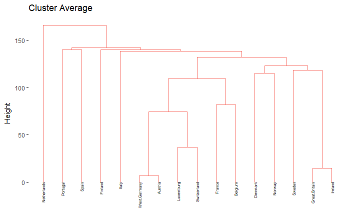

```r
fviz_dend(languages.average, main = "Cluster Average", cex = 0.4, label_cols = "black")
```

#### Exercise 2.2-b

Cluster Single: {Great-Britain, Ireland}, {West,Germany, Austria}, {Luxembourg, Switzerland}, {France, Belgium}, {Denmark, Norway}

Cluster Complete: {West,Germany, Austria}, {Luxembourg, Switzerland}, {Denmark, Norway}, {Great-Britain, Ireland}, {France, Belgium}

Cluster Average: {Portugal, Spain}, {West,Germany, Austria}, {Luxembourg, Switzerland}, {France, Belgium}, {Denmark, Norway}, {Great-Britain, Ireland}

#### Exercise 2.2-c

I think the single and average linkage strategy places Italy better than the complete linkage strategy because Italy is the only country with an Italian percentage above 25%. It makes sense that the country with no real relationship to the other countries is grouped into a large diverse cluster than a smaller closely-related cluster.

#### Exercise 2.2-d

Based on this heuristic of purity, the average linkage strategy if the most pure. It has 6 two-singleton clusters while the other two methods only have 5.

#### Exercise 2.2-e

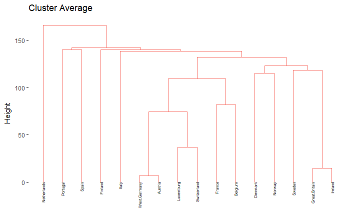

```r
fviz_dend(languages.average, main = "Cluster Average", cex = 0.4, label_cols = "black")
```

It looks like if we cut off the height at 125 we would get 7 clusters

#### Exercise 2.2-f

```r
languages.single7 <- eclust(languages.df, FUNcluster = "hclust", k = 7, hc_method = "single")
languages.complete7 <- eclust(languages.df, FUNcluster = "hclust", k = 7, hc_method = "complete")
languages.average7 <- eclust(languages.df, FUNcluster = "hclust", k = 7, hc_method = "average")
```

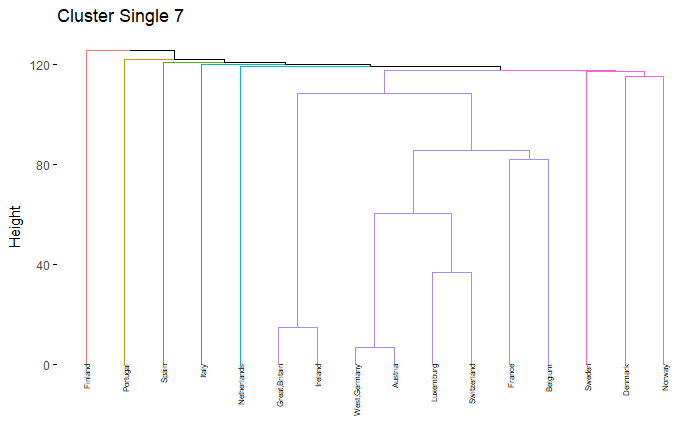

```r
fviz_dend(languages.single7, main = "Cluster Single 7", cex = 0.4, label_cols = "black")
```

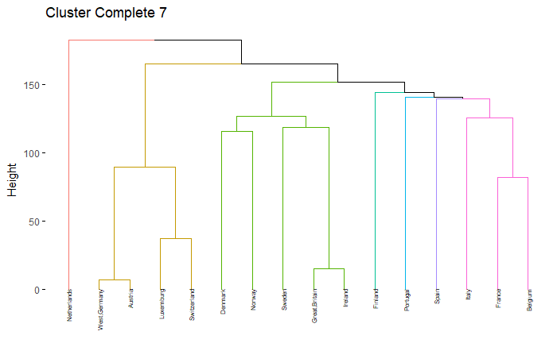

```r
fviz_dend(languages.complete7, main = "Cluster Complete 7", cex = 0.4, label_cols = "black")
```

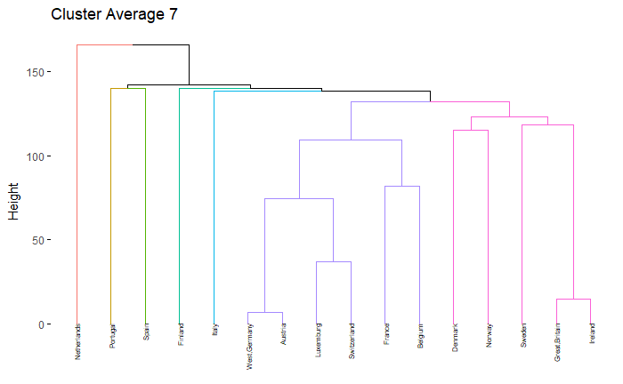

```r
fviz_dend(languages.average7, main = "Cluster Average 7", cex = 0.4, label_cols = "black")
```

#### Exercise 2.2-g

```r
library(cluster)
library(fpc)
single7.analysis <- cluster.stats(dist(languages.df), languages.single7$cluster)
complete7.analysis <- cluster.stats(dist(languages.df), languages.complete7$cluster)
average7.analysis <- cluster.stats(dist(languages.df), languages.average7$cluster)
```

#### Exercise 2.2-h

```r
single7.analysis$dunn
```

```
[1] 0.7813006
```

```r
complete7.analysis$dunn
```

```
[1] 0.6768822
```

```r
average7.analysis$dunn
```

```
[1] 0.807345
```

Based on the Dunn index, the average clustering method is the best.

```r
single7.analysis$avg.silwidth
```

```
[1] 0.1215148
```

```r
complete7.analysis$avg.silwidth
```

```
[1] 0.1922308
```

```r
average7.analysis$avg.silwidth
```

```
[1] 0.1698248
```

Based on the silhouette width, the complete clustering method is the best.

## Exercise 2.3

#### Exercise 2.3-a

```r
UCI.df <- read.csv("HTRU_2-small.csv")
UCI.pca <- prcomp(scale(UCI.df))
```

```r
UCI.pca$sdev
```

```
[1] 2.1800314 1.4745640 0.9027573 0.7071281 0.5635728 0.5110351 0.3829163 0.1318764 0.1238369
```

```r
UCI.pca$rotation
```

```
                       PC1        PC2          PC3         PC4         PC5           PC6         PC7         PC8         PC9
mean             0.3536414 -0.3123632 -0.007540726 -0.12958732  0.35946123 -0.7376228920  0.05524029 -0.28918817 -0.02315348
std.dev          0.2076659 -0.3974259 -0.475620066  0.69140918 -0.29343614 -0.0194317934 -0.06985115  0.05638231  0.01122309
kurtosis        -0.4052615  0.2733198 -0.073176092  0.18047068 -0.24301451 -0.1504711823 -0.06602287 -0.79465126 -0.07488506
skewness        -0.3845234  0.2642185 -0.053117584  0.04061818 -0.28797399 -0.6511396511 -0.06867632  0.51266480  0.05835695
mean.dm.snr     -0.3030808 -0.2866817 -0.542020239 -0.43252177 -0.10702648  0.0552039313  0.56738266 -0.02565137  0.08950623
std.dev.dm.snr  -0.3479499 -0.3480592 -0.213755075 -0.23057696  0.20834800  0.0659732114 -0.74610594 -0.01113829  0.23317205
kurtosis.dm.snr  0.3242511  0.4423604 -0.281236234 -0.02688055  0.04040671  0.0008206595 -0.01180192 -0.07863848  0.78192418
skewness.dm.snr  0.2524434  0.4246982 -0.574181288 -0.19121645  0.12667732  0.0205723834 -0.23167641  0.05639457 -0.56243334
class           -0.3713812  0.1434712 -0.131519313  0.43978842  0.75508568  0.0329638826  0.22490768  0.09353608  0.01440147
```

#### Exercise 2.3-a-i

```r
total <- 2.18 + 1.48 + 0.90 + 0.71 + 0.56 + 0.51 + 0.38 + 0.13 + 0.12
(2.18 + 1.48) / total
```

```
[1] 0.5251076
```

#### Exercise 2.3-a-ii

```r
library(devtools)
install_github('sinhrks/ggfortify')
library(ggfortify)
library(ggplot2)
```

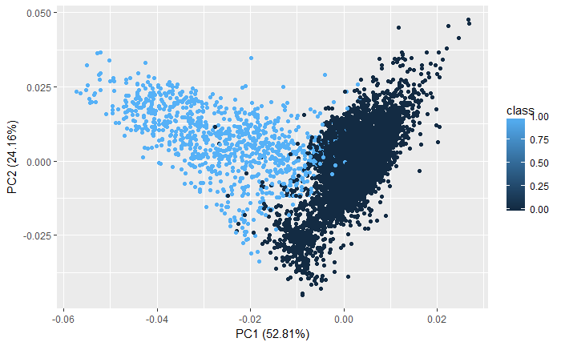

```r
autoplot(UCI.pca, data = UCI.df, colour = "class")
```

#### Exercise 2.3-a-iii

It looks like the class label is usually 0 when PC1 is >-0.01 and class 1 when PC1 is <=-0.01.

## Exercise 2.3-b

#### Exercise 2.3-b-i

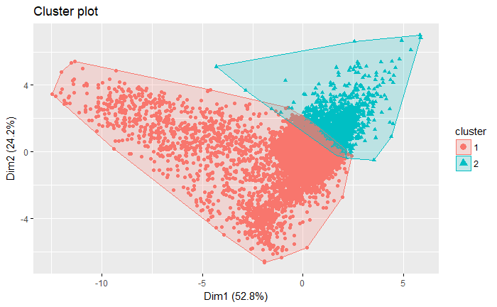

```r
UCI.k <- kmeans(UCI.df, centers=2, nstart=50)
fviz_cluster(UCI.k, data=UCI.df, geom="point")
```

#### Exercise 2.3-b-ii

There seem to be a lot more points in the left cluster and this is because k means groups on spatial locality while PCA groups based on predictors. Its interesting to note that x axis and y axis labels have similar %’s

#### Exercise 2.3-b-iii

```r
table(UCI.k$cluster)
```

```
   1    2
8514 1486
```

#### Exercise 2.3-b-iv

```r
table(UCI.df$class)
```

```
   0    1
9041  959
```

#### Exercise 2.3-b-v

I think cluster 1 is the majority class (class 0) and cluster 2 is the minority class (class 1)

#### Exercise 2.3-b-vi

```r
UCI.k.1 <- UCI.df[UCI.k$cluster==1,]
table(UCI.k.1$class)
```

```
   0    1
7570  944
```

#### Exercise 2.3-b-viii

```r
UCI.analysis <- cluster.stats(dist(UCI.df), UCI.k$cluster)
```

```r
UCI.k$betweenss / UCI.k$totss
```

```
[1] 0.4943605
```

49.44% of the variance is explained

#### Exercise 2.3-b-ix

```r
UCI.analysis$avg.silwidth
```

```
[1] 0.5903434
```

The average width is 0.59 for both clusters.

#### Exercise 2.3-b-x

```r
UCI.analysis$clus.avg.silwidths
```

```
        1         2
0.6205160 0.4174698
```

Based on this, the first cluster is better than the second cluster because it has a higher width.

## Exercise 2.3-c

```r
UCI.k.pca <- kmeans(UCI.pca$x[,1:2], centers=2, nstart=50)
```

#### Exercise 2.3-c-i

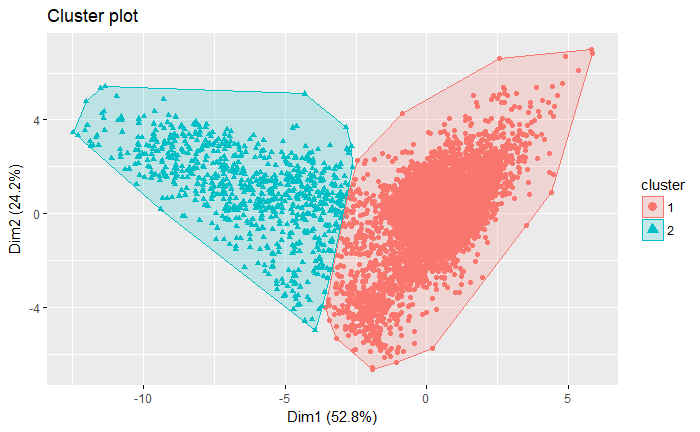

```r
fviz_cluster(UCI.k.pca, data=UCI.df, geom="point")
```

This shape is very similar to the graph in part a(ii) and not very similar to b(i).

#### Exercise 2.3-c-ii

```r
UCI.k.pca.analysis <- cluster.stats(dist(UCI.df), UCI.k.pca$cluster)
```

```r
UCI.k.pca.analysis$avg.silwidth
```

```
[1] 0.3067582
```

The average width for both clusters is 0.31

#### Exercise 2.3-c-iii

```r
UCI.k.pca.analysis$clus.avg.silwidths
```

```
        1         2
0.2857006 0.5502426
```

Based on this information Cluster 2 is pretty good and Cluster 1 is okay to not-so-good.

#### Exercise 2.3-c-iv

The average width of the clusters is lower in exercise c by quite a bit.The width of cluster 1 got a lot worse and the width of cluster 2 improved.